# Using sklearn and Pandas

`scikit-learn` and `pandas` are the common tools for data science in python.

```python
import pandas as pd
import sklearn
import numpy as np
import matplotlib.pyplot as plt
```

# Scikit-learn

`sklearn` has many of the tools needed to set up a data analysis pipeline:

- preprocessors
- models
- model selection

## Preprocessor

Preprocessors include

- `standardScaler`: shifts and scale the data to have mean 0 and standard deviation 1.
- `Normalizer`: normalises the features for each data sample to have unit lenght
- `MinMaxScaler`: shifts and scales the data so it fits in a given interval
- `OneHotEncoder`: transforms class labels to a one-hot encoded matrix of 0 or 1 values
- `PolynomialFeatures`: Creates polynomial features
- ...

## Models

in `sklearn.linear_model`:

- `LogisticRegression`: the logistic regression classifier discussed in Lecture 2.
- `Ridge`: the ridge regression discussed in Lecture 4
- `Perceptron`: the perceptron model discussed in Lecture 1

in `sklearn.neural_network`:

- `MLPclassifier`: the multiple layer perceptron 'classic' neural network discussed in lecture 5 and 6.

in `sklearn.neighbors`:

- `KNeighborsClassifier`: the $k$-neighbours classifier discussed in Lecture 7.

in sklearn.svm:

- `SVC`: the support vector classifier discussed in Lecture 3.

## Interface

The preprocessors and models in sklearn have a common functions:

- `fit`: fits to the data to set the model/preprocessor parameters
- `transform()`: transforms the input data and returns the transformed data
- `fit_transform()`: do both operations

Models have common functions:

- `predict(X)`: make a prediction for new data `X`
- `score(X,y)`: gives the score for data `X` and targets `y`

`fit` example

```python
from sklearn.preprocessing import StandardScaler
stdScaler = StandardScaler()
randomData = np.random.normal(2,3,size=(1000,1) )
stdScaler.fit(randomData)
```

```
StandardScaler(copy=True, with_mean=True, with_std=True)
```

After the fit the standard scaler has leaned the mean and standard deviation ot the dataset

```python
stdScaler.mean_, stdScaler.scale_
```

```
(array([1.93100284]), array([2.90804011]))
```

It can now apply the same transformation to unseen data:

```python
stdScaler.transform([
    [2],
    [5],
    [-1]
])
```

```
array([[ 0.02372635],
       [ 1.05534898],
       [-1.00789629]])
```

## Tools

in `model_selection`:

- `learning_curve`: can be used to produce learning curves.
- `train_test_split`: can be used to separate a given dataset in a training and validation sample.
- `GridSearchCV`: can be used to scan through a grid of parameter through cross validation.

## Model selection with `GridSearchCV`

We start with the same dataset as in one of the exercises:

```python
def fn(x):
    return 7-8*x-0.5*x**2+0.5*x**3

n_train = 100
np.random.seed(1122)
xs = np.linspace(0,5)
rxs = 5* np.random.random(n_train)
X1D = np.array([rxs]).T
ys1D = fn(rxs) + np.random.normal(size = (n_train) )
```

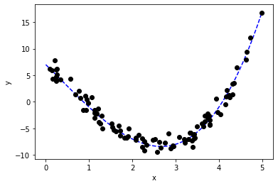

```python
plt.plot(xs, fn(xs),'b--')
plt.plot(rxs, ys1D,'ok')
plt.xlabel('x');
plt.ylabel('y');
```

```python
from sklearn.model_selection import GridSearchCV
from sklearn.linear_model import Ridge
from sklearn.preprocessing import PolynomialFeatures

polynomial_features= PolynomialFeatures(degree=8)
X_train = polynomial_features.fit_transform(X1D)

alpha_values = np.logspace(-4,4,100)
parameters = {'alpha':alpha_values}
r = Ridge()
Rsearch = GridSearchCV(r, parameters, cv=5)
Rsearch.fit(X_train, ys1D);
```

Our grid search has trained a ridge regression for each values of $\alpha$ and performed a 5-fold cross validation, so we will have access to an average and an uncertainty estimate.

```python
Rsearch.cv_results_.keys()
```

```
dict_keys(['mean_fit_time', 'std_fit_time', 'mean_score_time', 'std_score_time', 'param_alpha', 'params', 'split0_test_score', 'split1_test_score', 'split2_test_score', 'split3_test_score', 'split4_test_score', 'mean_test_score', 'std_test_score', 'rank_test_score'])
```

We can now plot the score as a function of $\alpha$:

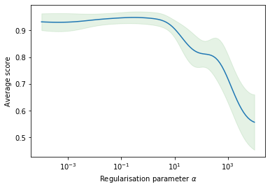

```python
scores = Rsearch.cv_results_['mean_test_score']
scores_std = Rsearch.cv_results_['std_test_score']
plt.fill_between(alpha_values, scores - scores_std,
                 scores + scores_std, alpha=0.1, color="g")
plt.plot(alpha_values, scores)
plt.xscale('log')
plt.xlabel(r'Regularisation parameter $\alpha$')
plt.ylabel('Average score');
```

We can access the best model using `best_estimator_`:

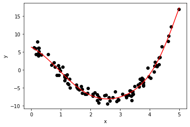

```python
xval = np.arange(0,5.1,0.1).reshape(-1, 1)
pxval = polynomial_features.transform(xval)
ypred = Rsearch.best_estimator_.predict(pxval)

plt.plot(rxs, ys1D,'ok')
plt.plot(xval, ypred , color='r')

plt.xlabel('x')
plt.ylabel('y');
```

## Pipelines

You noticed that we had to remember all the steps of the training to make the prediction of the model for the preceding plot. This is akward and error-prone.

We can use `Pipeline` to create all steps of an analysis in one object.

```python
from sklearn.pipeline import Pipeline

analysis_pipeline = Pipeline([
    ('poly', PolynomialFeatures(degree=8)),
    ('ridge', Ridge())
])
```

This pipeline can be used as a normal model, for example we can use it in a grid search:

```python
degrees = [5,6,7]
parameters = {
    'ridge__alpha': alpha_values,
    'poly__degree': degrees
}
Psearch = GridSearchCV(analysis_pipeline, parameters, cv=5)
Psearch.fit(X1D, ys1D);
```

Notice how parameters of specific steps can be set!

We can plot the scores for each polynomial order:

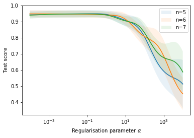

```python
for j in range(3):
    scores = Psearch.cv_results_['mean_test_score'][j*100:(j+1)*100]
    scores_std = Psearch.cv_results_['std_test_score'][j*100:(j+1)*100]
    plt.fill_between(alpha_values, scores - scores_std,
                 scores + scores_std, alpha=0.1, label="n={}".format(degrees[j]))
    plt.plot(alpha_values, scores)
plt.xscale('log')
plt.legend()
plt.xlabel(r'Regularisation parameter $\alpha$')
plt.ylabel('Test score');
```

And plot the best estimator's prediction:

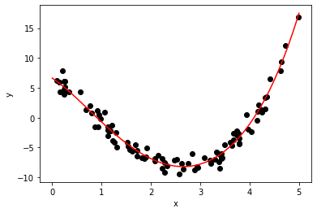

```python
xval = np.arange(0,5.1,0.1).reshape(-1, 1)
ypred = Psearch.best_estimator_.predict(xval)

plt.plot(rxs, ys1D,'ok')
plt.plot(xval, ypred , color='r')

plt.xlabel('x')
plt.ylabel('y');
```

Notice how we did not need to explicitely perform all the steps.

We can also use this estimator in other tools such as `learning_curve`:

```python
from sklearn.model_selection import learning_curve

train_sizes=np.linspace(.1, 1.0, 10)

train_sizes, train_scores, test_scores = learning_curve(
    Psearch.best_estimator_, X1D, ys1D, cv=5, train_sizes=train_sizes)

train_scores_mean = np.mean(train_scores, axis=1)
train_scores_std = np.std(train_scores, axis=1)
test_scores_mean = np.mean(test_scores, axis=1)
test_scores_std = np.std(test_scores, axis=1)
```

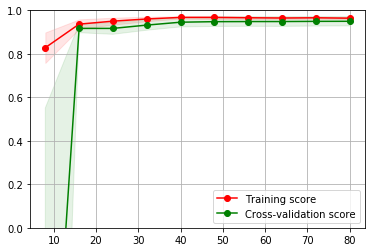

```python
plt.fill_between(train_sizes, train_scores_mean - train_scores_std,
                 train_scores_mean + train_scores_std, alpha=0.1, color="r")
plt.fill_between(train_sizes, test_scores_mean - test_scores_std,
                 test_scores_mean + test_scores_std, alpha=0.1, color="g")

plt.plot(train_sizes, train_scores_mean, 'o-', color="r",
         label="Training score")
plt.plot(train_sizes, test_scores_mean, 'o-', color="g",
         label="Cross-validation score")

plt.ylim(0,1); plt.grid(); plt.legend(loc="best");
```

# Pandas

Pandas uses `dataFrames` to represent data. Pandas has many helper functions to read data.

```python
df = pd.read_csv('grades.csv')
df
```

|  | name | Ex 1 | Ex 2 | Ex 3 | Ex 4 | passed |
| --- | --- | --- | --- | --- | --- | --- |
| 0 | John | 86 | 57 | 45 | 32 | true |
| 1 | Mary | 13 | 36 | 24 | 53 | false |
| 2 | Alice | 90 | 67 | 87 | 31 | true |
| 3 | Bob | 78 | 76 | 68 | 89 | true |
| 4 | Claire | 54 | 32 | 21 | 11 | false |

Common operations on a dataFrame:

Drop a row (return a new dataFrame)

```python
df.drop(2)
```

|  | name | Ex 1 | Ex 2 | Ex 3 | Ex 4 | passed |
| --- | --- | --- | --- | --- | --- | --- |
| 0 | John | 86 | 57 | 45 | 32 | true |
| 1 | Mary | 13 | 36 | 24 | 53 | false |
| 3 | Bob | 78 | 76 | 68 | 89 | true |
| 4 | Claire | 54 | 32 | 21 | 11 | false |

Drop several rows:

```python
df.drop([2,3,4])
```

|  | name | Ex 1 | Ex 2 | Ex 3 | Ex 4 | passed |
| --- | --- | --- | --- | --- | --- | --- |
| 0 | John | 86 | 57 | 45 | 32 | true |
| 1 | Mary | 13 | 36 | 24 | 53 | false |

Drop some columns

```python
df.drop('passed', axis=1)
```

|  | name | Ex 1 | Ex 2 | Ex 3 | Ex 4 |
| --- | --- | --- | --- | --- | --- |
| 0 | John | 86 | 57 | 45 | 32 |
| 1 | Mary | 13 | 36 | 24 | 53 |
| 2 | Alice | 90 | 67 | 87 | 31 |
| 3 | Bob | 78 | 76 | 68 | 89 |
| 4 | Claire | 54 | 32 | 21 | 11 |

Drop several columns:

```python
df.drop(['Ex 2', 'Ex 3'], axis=1)
```

|  | name | Ex 1 | Ex 4 | passed |
| --- | --- | --- | --- | --- |
| 0 | John | 86 | 32 | true |
| 1 | Mary | 13 | 53 | false |
| 2 | Alice | 90 | 31 | true |
| 3 | Bob | 78 | 89 | true |
| 4 | Claire | 54 | 11 | false |

Transform columns:

```python
df['passed'].apply(lambda x: x=='true')
```

```
0     True
1    False
2     True
3     True
4    False
Name: passed, dtype: bool
```

The dataFrame is not modified!

```python
df
```

|  | name | Ex 1 | Ex 2 | Ex 3 | Ex 4 | passed |
| --- | --- | --- | --- | --- | --- | --- |
| 0 | John | 86 | 57 | 45 | 32 | true |
| 1 | Mary | 13 | 36 | 24 | 53 | false |
| 2 | Alice | 90 | 67 | 87 | 31 | true |
| 3 | Bob | 78 | 76 | 68 | 89 | true |
| 4 | Claire | 54 | 32 | 21 | 11 | false |

To modify it assign the modified column to istself:

```python
df['passed'] = df['passed'].apply(lambda x: x=='true')
df
```

|  | name | Ex 1 | Ex 2 | Ex 3 | Ex 4 | passed |
| --- | --- | --- | --- | --- | --- | --- |
| 0 | John | 86 | 57 | 45 | 32 | True |
| 1 | Mary | 13 | 36 | 24 | 53 | False |
| 2 | Alice | 90 | 67 | 87 | 31 | True |
| 3 | Bob | 78 | 76 | 68 | 89 | True |
| 4 | Claire | 54 | 32 | 21 | 11 | False |

Create new columns:

```python
df['average'] = (df['Ex 1'] + df['Ex 2']+df['Ex 3']+df['Ex 4'])/ 4
df
```

|  | name | Ex 1 | Ex 2 | Ex 3 | Ex 4 | passed | average |
| --- | --- | --- | --- | --- | --- | --- | --- |
| 0 | John | 86 | 57 | 45 | 32 | True | 55.00 |
| 1 | Mary | 13 | 36 | 24 | 53 | False | 31.50 |
| 2 | Alice | 90 | 67 | 87 | 31 | True | 68.75 |
| 3 | Bob | 78 | 76 | 68 | 89 | True | 77.75 |
| 4 | Claire | 54 | 32 | 21 | 11 | False | 29.50 |

```python
df['mention'] = df['average'] > 70
df
```

|  | name | Ex 1 | Ex 2 | Ex 3 | Ex 4 | passed | average | mention |
| --- | --- | --- | --- | --- | --- | --- | --- | --- |
| 0 | John | 86 | 57 | 45 | 32 | True | 55.00 | False |
| 1 | Mary | 13 | 36 | 24 | 53 | False | 31.50 | False |
| 2 | Alice | 90 | 67 | 87 | 31 | True | 68.75 | False |
| 3 | Bob | 78 | 76 | 68 | 89 | True | 77.75 | True |
| 4 | Claire | 54 | 32 | 21 | 11 | False | 29.50 | False |

DataFrames can be used as input to `sklearn` functions.

```python
from sklearn.preprocessing import StandardScaler
sScaler = StandardScaler()
```

```python
firstTerm = df[['Ex 1', 'Ex 2']]
sScaler.fit(firstTerm)
```

```
StandardScaler(copy=True, with_mean=True, with_std=True)
```

```python
sScaler.transform(firstTerm)
```

```
array([[ 0.76533169,  0.19834601],
       [-1.79747626, -1.02673227],
       [ 0.90575952,  0.78171661],
       [ 0.48447602,  1.30675016],
       [-0.35809097, -1.26008051]])
```

```python
from sklearn.neighbors import KNeighborsClassifier
```

```python
kn = KNeighborsClassifier(n_neighbors=2)
kn.fit(df[['Ex 1','Ex 2', 'Ex 3', 'Ex 4']],df['passed'])
```

```
KNeighborsClassifier(algorithm='auto', leaf_size=30, metric='minkowski',
                     metric_params=None, n_jobs=None, n_neighbors=2, p=2,
                     weights='uniform')
```

```python
kn.predict([
    [10,10,10,10],
    [50,60,70,80]
])
```

```
array([False,  True])
```